# Verzani Problem Set

### Problem 3.5

Lets review `bumpers`, `firstchi` and `math` data frames from `UsingR` package. What data are they containing?

```r
> ?bumpers
> ?firstchi
> ?math
```

`bumpers` data frame contains bumper repair costs for various automobiles. `firstchi` data frame contains age of mother at birth of first child. `math` data frame contains standardized math scores.

Now lets review what are this data sets containing

```r
> head(bumpers)
      Honda Accord Chevrolet Cavalier       Toyota Camry         Saturn SL2
               618                795               1304               1308
 Mitsubishi Galant       Dodge Monaco
              1340               1456
> head(firstchi)
[1] 30 18 35 22 23 22
> head(math)
[1] 44 49 62 45 51 59
```

Make a histogram for every one of them. Try to predict the mean, median and standard deviation of every one of them. Check your guesses with the appropriate R commands.

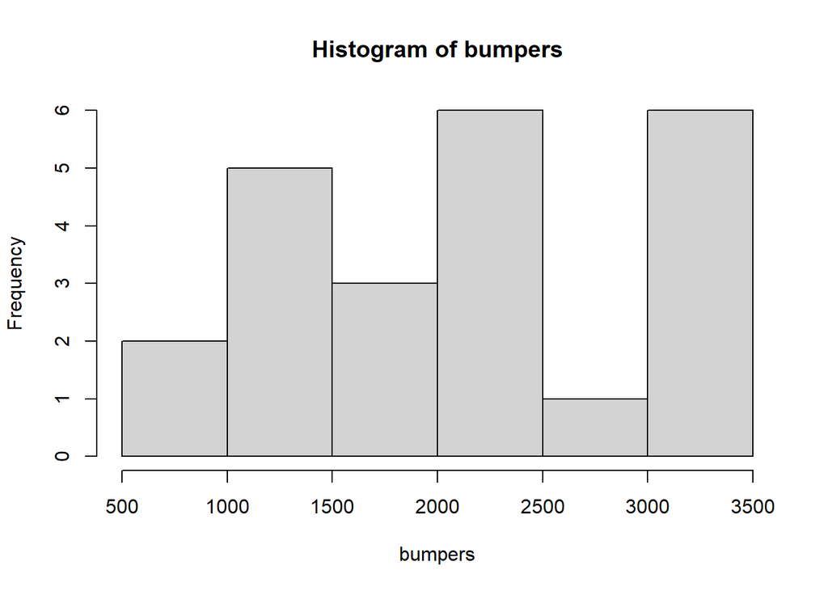

```r
> hist(bumpers)
```

```r
> summary(bumpers)
   Min. 1st Qu.  Median    Mean 3rd Qu.    Max.
    618    1478    2129    2122    2774    3298
> sd(bumpers)
[1] 798.4574
```

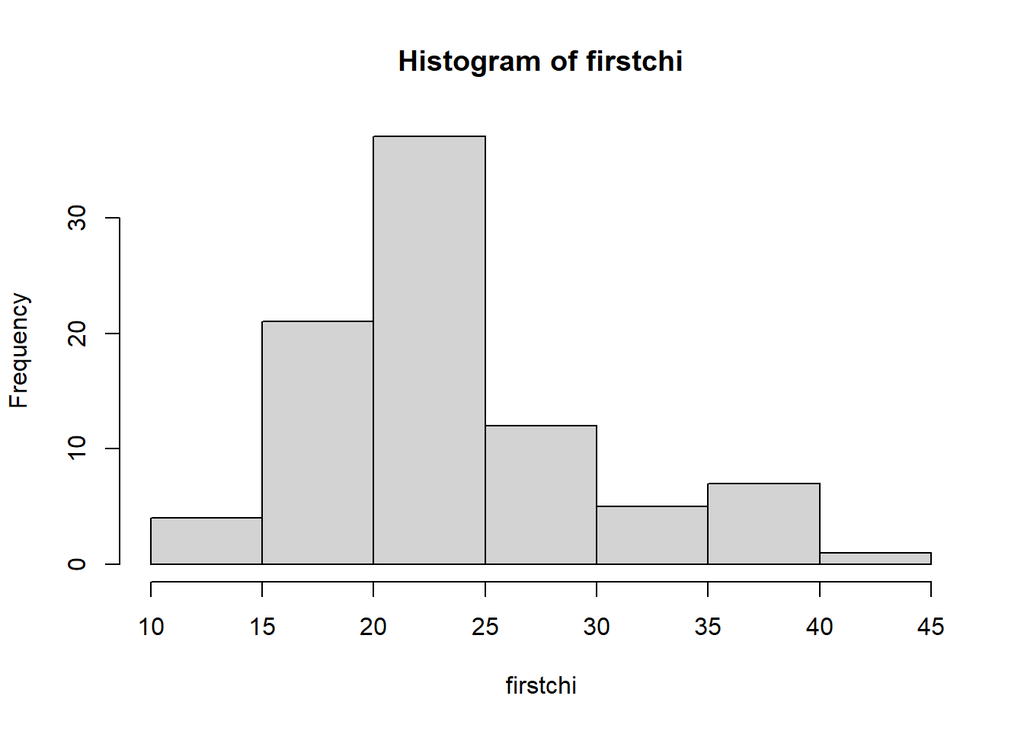

```r
> hist(firstchi)
```

```r
> summary(firstchi)
   Min. 1st Qu.  Median    Mean 3rd Qu.    Max.
  14.00   20.00   23.00   23.98   26.00   42.00
> sd(firstchi)
[1] 6.254258
```

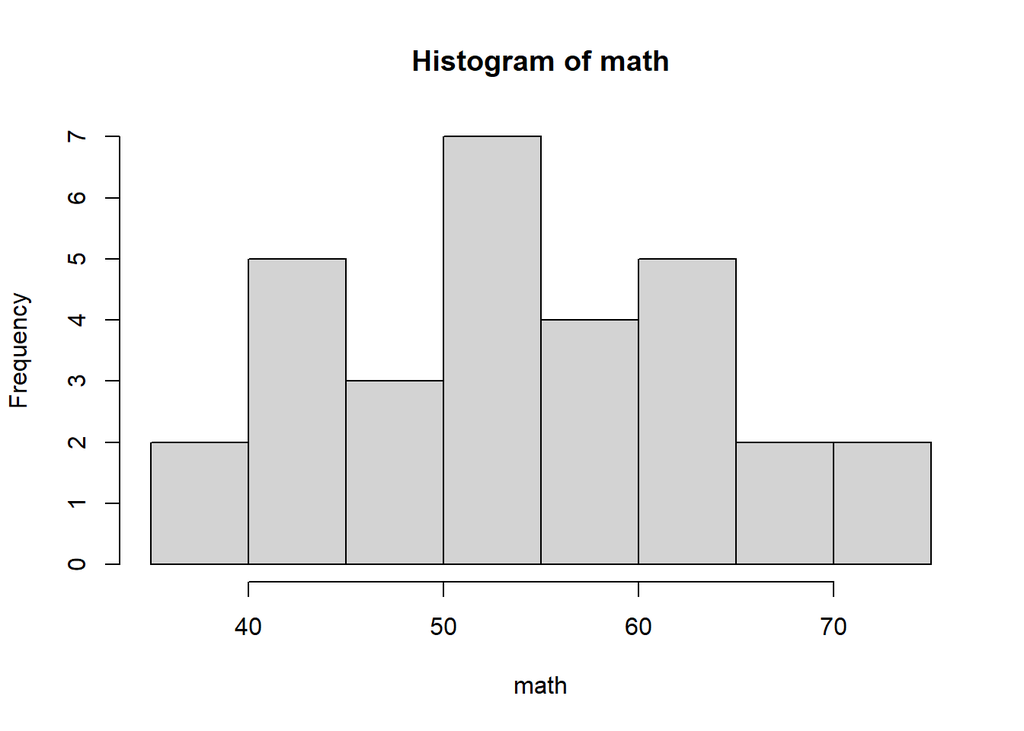

```r
> hist(math)
```

```r
> summary(math)
   Min. 1st Qu.  Median    Mean 3rd Qu.    Max.
  38.00   49.00   54.00   54.90   61.75   75.00
> sd(math)
[1] 9.746264
```

### Problem 3.6

The number of O-ring failures for the first $23$ flights of the US space shuttle Challenger were
$$0,\ 1,\ 0,\ NA,\ 0,\ 0,\ 0,\ 0,\ 0,\ 1,\ 1,\ 1,\ 0,\ 0,\ 3,\ 0,\ 0,\ 0,\ 0,\ 0,\ 2,\ 0,\ 1$$
(`NA` means not available - the equipment was lost).

Make a table of the possible categories.

```r
> failures <- c(0, 1, 0, NA, 0, 0, 0, 0, 0, 1, 1, 1, 0, 0, 3, 0, 0, 0, 0, 0, 2, 0, 1)
> table(failures, useNA = "ifany")
failures
   0    1    2    3 <NA>
  15    5    1    1    1
```

Try to find the mean.

```r
> mean(failures, na.rm = TRUE)
[1] 0.4545455
```

or

```r
> mean(failures[!is.na(failures)])
[1] 0.4545455
```

### Problem 3.7

The `pi2000` data frames from `UsingR` package contains the first 2000 digits of $\pi$. Make a histogram.

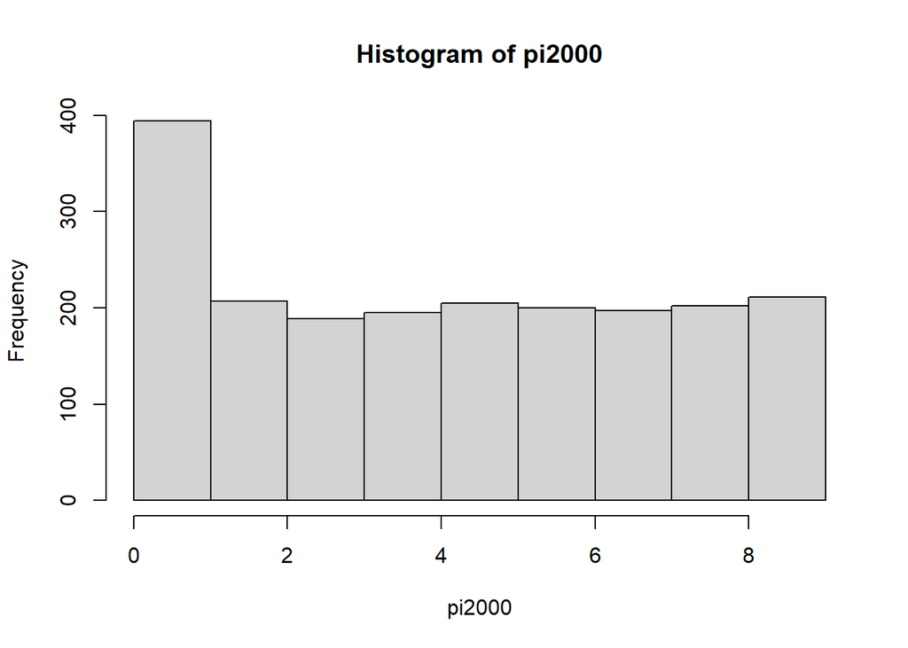

```r
> hist(pi2000)
```

Is it surprising? Find the proportion of 1’s, 2’s and so on.

```r
> table(pi2000)
pi2000
  0   1   2   3   4   5   6   7   8   9
181 213 207 189 195 205 200 197 202 211
> table(pi2000) / length(pi2000)
pi2000
     0      1      2      3      4      5      6      7      8      9
0.0905 0.1065 0.1035 0.0945 0.0975 0.1025 0.1000 0.0985 0.1010 0.1055
> prop.table(table(pi2000))
pi2000
     0      1      2      3      4      5      6      7      8      9
0.0905 0.1065 0.1035 0.0945 0.0975 0.1025 0.1000 0.0985 0.1010 0.1055
> proportions(table(pi2000))
pi2000
     0      1      2      3      4      5      6      7      8      9
0.0905 0.1065 0.1035 0.0945 0.0975 0.1025 0.1000 0.0985 0.1010 0.1055
```

### Problem 3.8

Fit a density estimate to the `pi2000` data frame.

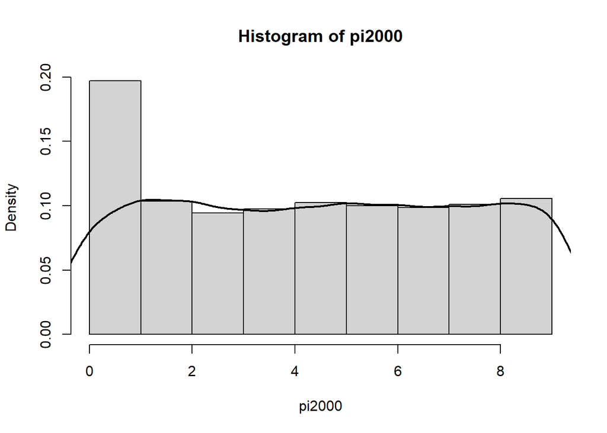

```r
> density(pi2000)

Call:
    density.default(x = pi2000)

Data: pi2000 (2000 obs.);   Bandwidth 'bw' = 0.5657

       x                y
 Min.   :-1.697   Min.   :0.0007207
 1st Qu.: 1.401   1st Qu.:0.0755293
 Median : 4.500   Median :0.0990100
 Mean   : 4.500   Mean   :0.0805830
 3rd Qu.: 7.599   3rd Qu.:0.1007573
 Max.   :10.697   Max.   :0.1046462
> hist(pi2000, probability = TRUE)
> lines(density(pi2000), lwd = 2)
```